# CanvasXpress: Facet Chart

Area

AreaLine

Bar

BarLine

[figure not shown]

Boxplot

Bubble

Chord

[figure not shown]

Circular

Contour

Correlation

Dashboard

Density

Donnut

DotLine

Dotplot

[figure not shown]

Facet

Fish

Functions

Gantt

Genome

Heatmap

Hexplot-Binplot

Histogram

Kaplan-Meier

[figure not shown]

Layout

Line

Linear-Fit

Lollipop

Map

Meter

Network

NonLinear-Fit

[figure not shown]

Oncoprint

[figure not shown]

ParallelCoordinates

Pie

Radar

Remote-Graphs

Ridge-Line

[figure not shown]

SPLOM

Sankey

Scatter2D

Scatter3D

ScatterBubble2D

Stacked

StackedLine

StackedPercent

[figure not shown]

StackedPercentLine

Streamgraph

Sunburst

TCGA

[figure not shown]

TagCloud

Tree

Treemap

[figure not shown]

UpSet

Venn

Violin

Waterfall

## Facet Chart

Facets allow to segregate a data set based on variable or sample meta data. Here are some examples using bar graphs and scatter plots.

Example Color Themes

Example Fonts

Aa Aa Aa Aa Aa Aa Aa Aa Aa Aa

[interactive chart not shown]

Show Code

Tools

**HTML / JS**

```javascript
<!-- Include the CanvasXpress library in your HTML file -->
<link rel="stylesheet" href="https://www.canvasxpress.org/dist/canvasXpress.css" type="text/css"/>
<script src="https://www.canvasxpress.org/canvasXpress.min.js"></script>


<!-- Create a canvas element for the chart with the desired dimensions -->
<div>
  <canvas id="canvasId" width="600" height="600"</canvas>
</div>


<!-- Create a script to initialize the chart -->
<script>

  <!-- Create the data for the graph -->
  var data = {
     "y" : {
        "data" : [
          [38.4,27.7,25.7,53.1,30.6,30.2],
          [46.2,57.2,41.9,54.7,43.3,56.7],
          [72.5,57.9,51.9,74.2,53.4,42.4],
          [38,38,32.2,49.6,37.4,34.4],
          [82.8,57.9,64.7,53.6,48.6,44.8],
          [33.9,32,31.4,51.3,35.5,42.9],
          [50.4,40.6,40.1,44.1,46.9,42.7],
          [35,33.1,43.2,34,26.4,24.8],
          [32.8,26.8,33.9,34.5,25.1,25.1],
          [60.1,53.2,40.4,59.1,87.1,59.2],
          [75.1,63.1,58,67.3,43.8,42.2],
          [57.6,57.7,61.5,75.5,126.6,48.4],
          [55.5,63.3,44.6,41.1,41.8,32],
          [49.5,45.8,35.3,52.2,53.8,48.1],
          [40.9,35.7,37.2,28.3,26,33.7],
          [44.3,46.8,39.4,74.9,45.3,42.6],
          [93.8,91.9,77.4,77.5,55.8,54.9],
          [47.9,59.9,52.8,50.9,58.6,64.5],
          [75.2,54.1,63.6,70.1,44,43.1],
          [46.2,39.3,56.6,60.3,47.8,52.8],
          [56.3,45.8,58.9,59.9,36.8,44.3]
        ],
        "desc" : ["time in seconds"],
        "smps" : ["U-Trial 1","U-Trial 2","U-Trial 3","S-Trial 1","S-Trial 2","S-Trial 3"],
        "vars" : ["s1","s2","s3","s4","s5","s6","s7","s8","s9","s10","s11","s12","s13","s14","s15","s16","s17","s18","s19","s20","s21"]
     },
     "z" : {
        "Age" : [23,43,43,32,15,37,26,35,26,31,35,55,25,39,25,26,33,62,54,38,65],
        "Opinion" : ["pos","neg","pos","neg","neg","pos","pos","pos","pos","indiff","pos","indiff","pos","indiff","indiff","pos","neg","neg","pos","neg","neg"],
        "Order" : ["1","2","1","2","1","2","1","2","1","2","1","2","1","2","1","2","1","2","1","2","1"],
        "Sex" : ["M","F","M","M","M","F","F","F","M","F","F","F","F","M","M","M","M","M","F","F","M"],
        "Smoker" : ["N","Y","N","N","N","Y","N","N","N","N","Y","Y","Y","Y","N","N","Y","N","Y","N","N"]
     }
  }


  <-- Create the configuration for the graph -->
  var config = {
     "graphType":"Scatter2D",
     "layoutCollapse":"false",
     "layoutType":"cols",
     "legendBox":"true",
     "shapeBy":"Age",
     "showTransition":"false",
     "theme":"CanvasXpress",
     "title":"Floral scent data set",
     "xAxis":[
        "U-Trial 1",
        "U-Trial 2",
        "U-Trial 3"
     ],
     "yAxis":[
        "S-Trial 1",
        "S-Trial 2",
        "S-Trial 3"
     ]
  }


  <!-- Call the CanvasXpress function to create the graph -->
  var cX = new CanvasXpress("canvasId", data, config);



  <-- Functions after rendering graph -->
  cX.segregateVariables(["Opinion", "Sex"]);

</script>
```

**R Code**

[figure not shown]

[figure not shown]

[figure not shown]

[figure not shown]

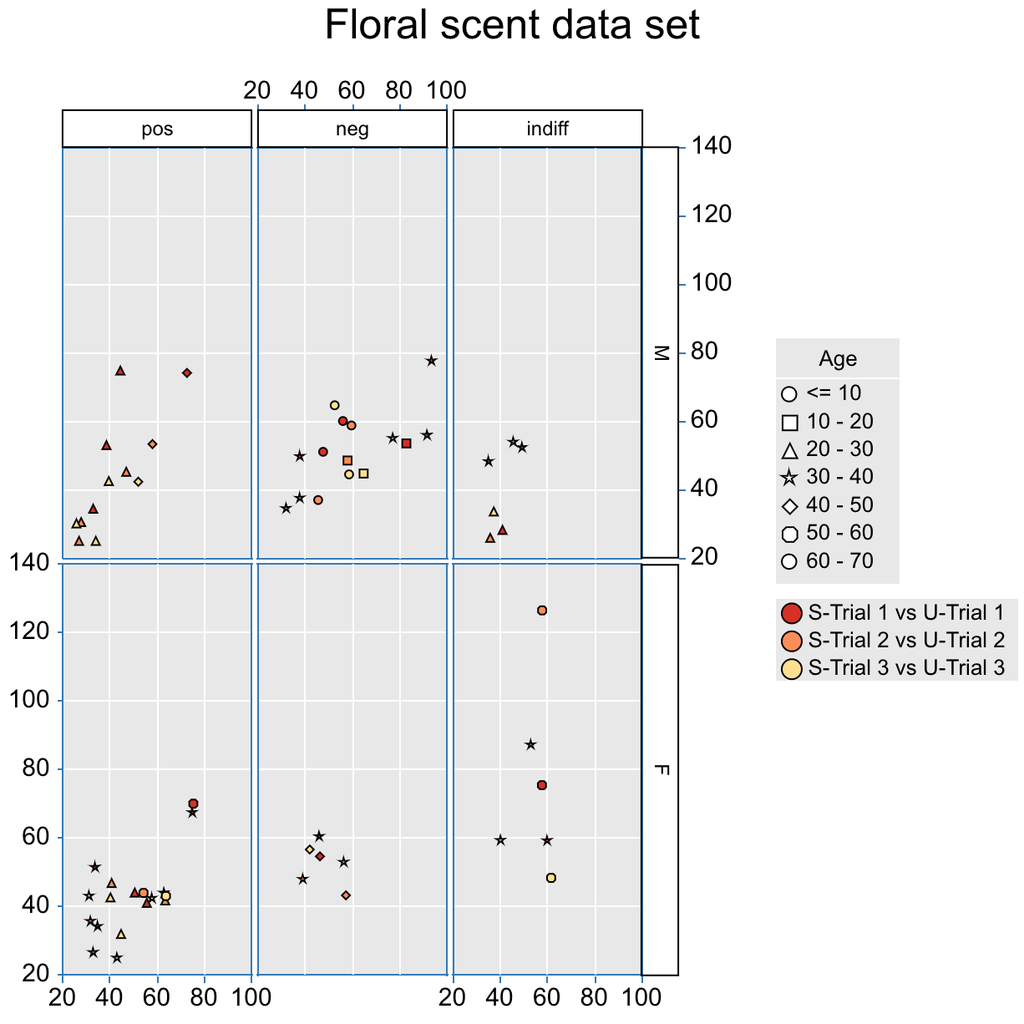

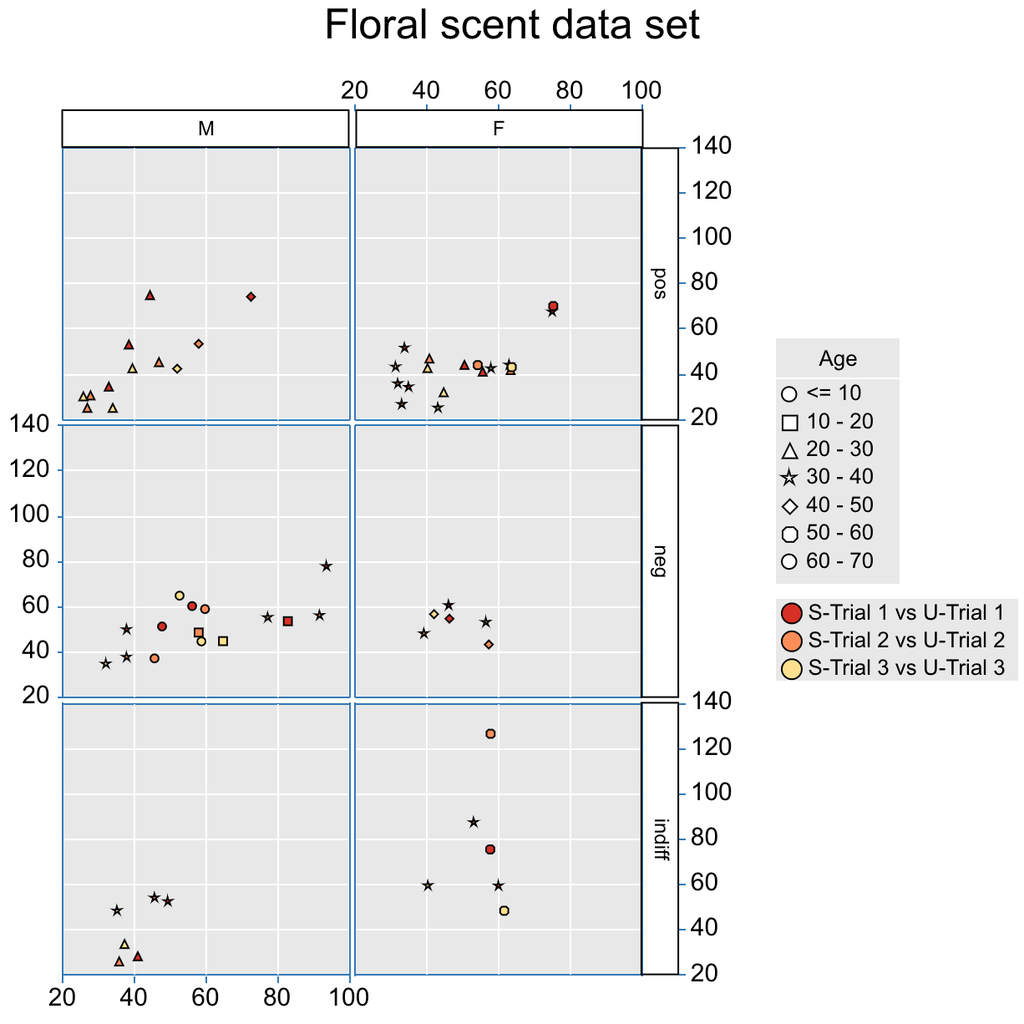

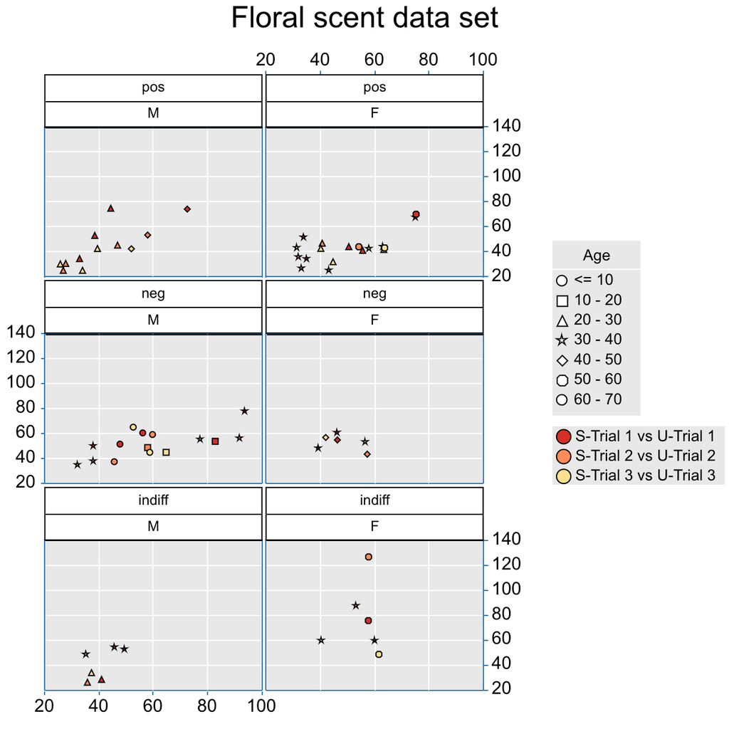

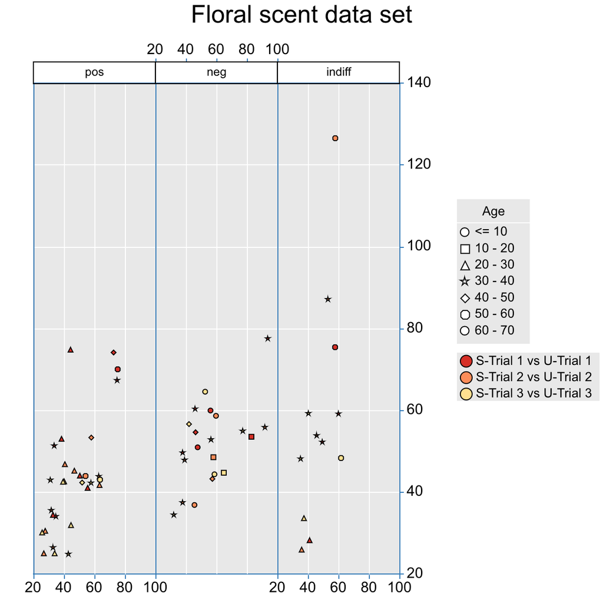

```r
library(canvasXpress)
y=read.table("https://www.canvasxpress.org/data/cX-scentst-dat.txt", header=TRUE, sep="\t", quote="", row.names=1, fill=TRUE, check.names=FALSE, stringsAsFactors=FALSE)
z=read.table("https://www.canvasxpress.org/data/cX-scentst-var.txt", header=TRUE, sep="\t", quote="", row.names=1, fill=TRUE, check.names=FALSE, stringsAsFactors=FALSE)
canvasXpress(
  data=y,
  varAnnot=z,
  graphType="Scatter2D",
  layoutCollapse=FALSE,
  layoutType="cols",
  legendBox=TRUE,
  shapeBy="Age",
  showTransition=FALSE,
  theme="CanvasXpress",
  title="Floral scent data set",
  xAxis=list("U-Trial 1", "U-Trial 2", "U-Trial 3"),
  yAxis=list("S-Trial 1", "S-Trial 2", "S-Trial 3"),
  afterRender=list(list("segregateVariables", list(list("Opinion", "Sex"))))
)
```

Show All

⇧